# Power analyses for OTM2

Frederik Aust

04 May, 2020

```r
pes_to_dz <- function(pes, n, n_groups = 2) {
  # I *think* sqrt(n_groups) is needed because of the between subject factor
  # either way I validate that the results for pes, f, and dz are correct
  sqrt(((1 - n) * pes)/(n * (pes - 1))) * sqrt(n_groups)
}

dz_to_f <- function(dz, rho) {
  0.5 * dz * sqrt(2 * (1 - rho))
}

pes_to_f <- function(pes, n, rho) {
  dz <- pes_to_dz(pes, n)
  dz_to_f(dz, rho)
}

f_to_dz <- function(f, rho) {
  (sqrt(2) * f) / sqrt(1 - rho)
}

dz_to_pes <- function(dz, n, n_groups = 2) {
  (dz^2 * n)/(dz^2 * n + n*n_groups - n_groups)
}
```

Because it grants greater flexibility for ANOVA designs, I here used the in-development R package `Superpower`. The make sure I’m doing this right, I first reproduced the power analyses done in G*Power for OTM1.

# 1 OTM 1

The following gives the interaction power for the effect size estimated in the G*Power sensitivity analysis

```r
contrast_code <- tibble::tibble(
  a = rep(contr.sum(2), 2)
  , b = rep(contr.sum(2), each = 2)
  , x = a*b * -1
)$x

f <- 0.1481313
mu <- f * contrast_code
n <- 75
r <- 0.5
alpha_level <- 0.05

string <- "2w*2b"
labelnames <- c("block", "1", "2", "order", "n-p", "p-n")

design_result <- ANOVA_design(
  design = string
  , n = n
  , mu = mu
  , sd = 1
  , r = r
  , labelnames = labelnames
)

otm1_power <- ANOVA_exact(
  design_result
  , alpha_level = alpha_level
  , emm = TRUE
  , verbose = FALSE
  , contrast_type = "pairwise"
  , emm_comp = "block | order"
)

otm1_power$main_results
```

|  | power | partial_eta_squared | cohen_f | non_centrality |
| --- | --- | --- | --- | --- |
| order | 5.00000 | 0.0000000 | 0.0000000 | 0.00000 |
| block | 5.00000 | 0.0000000 | 0.0000000 | 0.00000 |
| order:block | 94.99999 | 0.0816906 | 0.2982577 | 13.16573 |

as well as the power for the block contrasts

```r
otm1_power$emm_results
```

| contrast | order | power | partial_eta_squared | cohen_f | non_centrality |
| --- | --- | --- | --- | --- | --- |
| block_1 - block_2 | order_n-p | 72.20945 | 0.0425847 | 0.2109 | 6.582865 |
| block_1 - block_2 | order_p-n | 72.20945 | 0.0425847 | 0.2109 | 6.582865 |

However, this doesn’t give the result for the desired contrast that collapses over the counterbalancing factor, nor for a directional test. I contributed a pull request to `Superpower` to enable power analyses for contrasts specified with `emmeans`. The following gives the result for the collapsed contrast

```r
custom_contrast <- contrast(
  emmeans(
    otm1_power$emmeans$emmeans
    , specs = ~ order * block
  )
  , list(block_effect = c(0.5, -0.5, -0.5, 0.5))
)

emmeans_power(custom_contrast, alpha_level = 0.05)
```

| contrast | power | partial_eta_squared | cohen_f | non_centrality |
| --- | --- | --- | --- | --- |
| block_effect | 94.99999 | 0.0816906 | 0.2982577 | 13.16573 |

which is the same as doing a within-subject t-test in this case.

```r
pwr.t.test(n = 150, d = 2*f, sig.level = 0.05, type = "paired")
```

```
##
##      Paired t test power calculation
##
##               n = 150
##               d = 0.2962626
##       sig.level = 0.05
##           power = 0.9500163
##     alternative = two.sided
##
## NOTE: n is number of *pairs*
```

To get the power for the directional test, I can increase the alpha level as needed, which shows that this contrast is the same as the within-subject t-test collapsing data across groups.

```r
emmeans_power(custom_contrast, alpha_level = 0.1)
```

| contrast | power | partial_eta_squared | cohen_f | non_centrality |
| --- | --- | --- | --- | --- |
| block_effect | 97.54055 | 0.0816906 | 0.2982577 | 13.16573 |

```r
pwr.t.test(150, sig.level = 0.05, d = 2*f, type = "paired", alternative = "greater")
```

```
##
##      Paired t test power calculation
##
##               n = 150
##               d = 0.2962626
##       sig.level = 0.05
##           power = 0.9754119
##     alternative = greater
##
## NOTE: n is number of *pairs*
```

This now also allows me to get the power for the one-sided tests of the uncollapsed contrasts

```r
emmeans_power(otm1_power$emmeans$contrasts, alpha_level = 0.1)
```

| contrast | order | power | partial_eta_squared | cohen_f | non_centrality |
| --- | --- | --- | --- | --- | --- |
| block_1 - block_2 | order_n-p | 81.83646 | 0.0425847 | 0.2109 | 6.582865 |
| block_1 - block_2 | order_p-n | 81.83646 | 0.0425847 | 0.2109 | 6.582865 |

Anyway, the following reproduces the G*Power sensitivity analysis for the collapsed contrast.

```r
pwr.t.test(150, sig.level = 0.05, power = 0.95, type = "paired", alternative = "greater")
```

```
##
##      Paired t test power calculation
##
##               n = 150
##               d = 0.2698232
##       sig.level = 0.05
##           power = 0.95
##     alternative = greater
##
## NOTE: n is number of *pairs*
```

## 1.1 With implicit repeated measures correlation

```r
rydell_pes <- 0.1
rydell_f <- 4.78
rydell_n <- 50
rydell_dz <- pes_to_dz(rydell_pes, rydell_n, n_groups = 2)


heycke_t <- c(2.54, 1.45)
heycke_n <- c(28, 26)
heycke_dz <- heycke_t / sqrt(heycke_n)
heycke_pes <- dz_to_pes(heycke_dz, heycke_n, n_groups = 1)
# heycke_pes <- (heycke_dz^2 * heycke_n) / (heycke_dz^2 * heycke_n + heycke_n - 1) # pes

# mean(c(heycke_dz, rydell_dz))
# mean(c(heycke_pes, rydell_pes))
```

To simplify this, I will focus on the power for what we’d expect to be the smallest effect: The *learning block* contrast within each *valence order* group in IAT scores. Rydell et al. report the smallest contrast as $\eta_p^2 = 0.1$ ($d_z \approx 0.4666667$), which is comparable in magnitude (but not direction) to the corresponding effect sizes reported by Heycke et al.

```r
otm1_power <- function(f, rm_cor, n = 76, alpha = 0.05) {
  contrast_code <- tibble::tibble(
    a = rep(contr.sum(2), 2)
    , b = rep(contr.sum(2), each = 2)
    , x = a*b * -1
  )$x

  mu <- f * contrast_code

  cor_mat <- diag(4)
  triangular <- c(0, 1, 0, 0, 1, 0)
  cor_mat[upper.tri(cor_mat)] <- triangular * rm_cor
  cor_mat[lower.tri(cor_mat)] <- triangular * rm_cor

  string <- "2w*2b"
  labelnames <- c("block", "1", "2", "order", "n-p", "p-n")

  design_result <- ANOVA_design(
    design = string
    , n = n
    , mu = mu
    , sd = 1
    , r = cor_mat
    , labelnames = labelnames
  )

  otm1_power <- ANOVA_exact(
    design_result
    , alpha_level = alpha
    , emm = TRUE
    , verbose = FALSE
    , contrast_type = "pairwise"
    , emm_comp = "block | order"
  )

  otm1_power
}
```

```r
otm1_n <- 76

# 95% power
otm1_pes <- 0.08068
otm1_dz <- pes_to_dz(otm1_pes, otm1_n, n_groups = 2)
# rho <- 0.5
# f <- dz_to_f(otm1_dz, rho)
#
# otm1_contrast_power <- otm1_power(f = f, n = otm1_n, rm_cor = rho)$emmeans$contrasts %>%
#   emmeans_power(alpha = 0.05) %>%
#   .[1, ]
# otm1_contrast_power

# 80% power
otm1_pes2 <- 0.050336
otm1_dz2 <- pes_to_dz(otm1_pes2, otm1_n, n_groups = 2)
# f <- dz_to_f(otm1_dz2, rho)
#
# otm1_contrast_power2 <- otm1_power(f = f, n = otm1_n, rm_cor = rho)$emmeans$contrasts %>%
#   emmeans_power(alpha = 0.05) %>%
#   .[1, ]
# otm1_contrast_power2
```

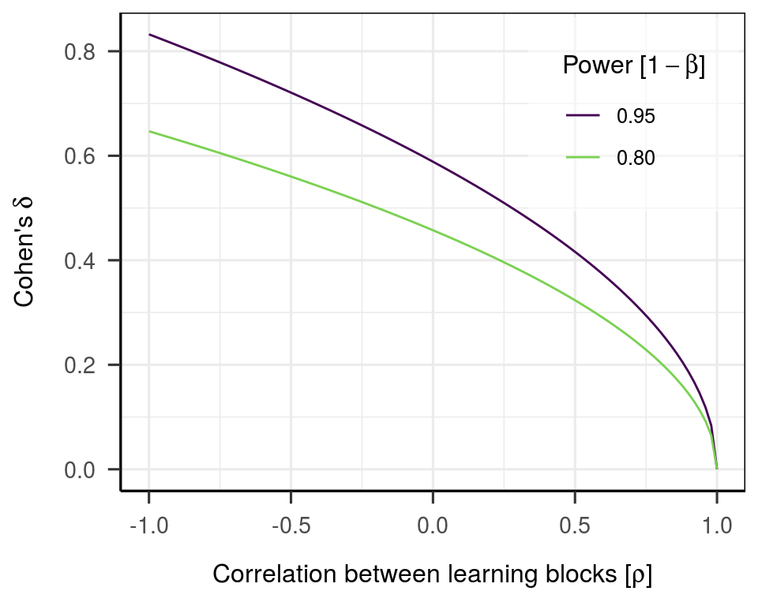

Figure 1.1: Sensitivity curve for OTM1

```r
tibble(
  rho = rep(seq(-1, 1, length.out = 100), 2)
  , delta = c(
    dz_to_f(otm1_dz, unique(rho)) * 2
    , dz_to_f(otm1_dz2, unique(rho)) * 2
  )
  , power = rep(c("0.95", "0.80"), each = length(rho)/2)
) %>%
  mutate(power = relevel(factor(power), "0.95")) %>%
  ggplot(aes(x = rho, y = delta, color = power, group = power)) +
  geom_line() +
  scale_color_viridis_d(end = 0.8) +
  labs(
    x = bquote("Correlation between learning blocks ["*rho*"]")
    , y = bquote("Cohen's"~delta)
    , color = bquote("Power"~"["*1 - beta*"]")
  ) +
  theme_apa(box = TRUE) +
  theme(
    panel.grid.major.x = element_line()
    , panel.grid.major.y = element_line()
    , panel.grid.minor.x = element_line()
    , panel.grid.minor.y = element_line()
    , legend.position = c(0.99, 0.99)
    , legend.justification = c(1, 1)
    , legend.background = element_rect(fill = scales::alpha("white", 0.5))
  )
```

# 2 OTM 2

## 2.1 By measure

Because `Superpower` only allows for power analyses, I manually determined the sample size that yields approximately 95% power. The following assumes that we are not interested in the effect of the counterbalancing factor *order*.

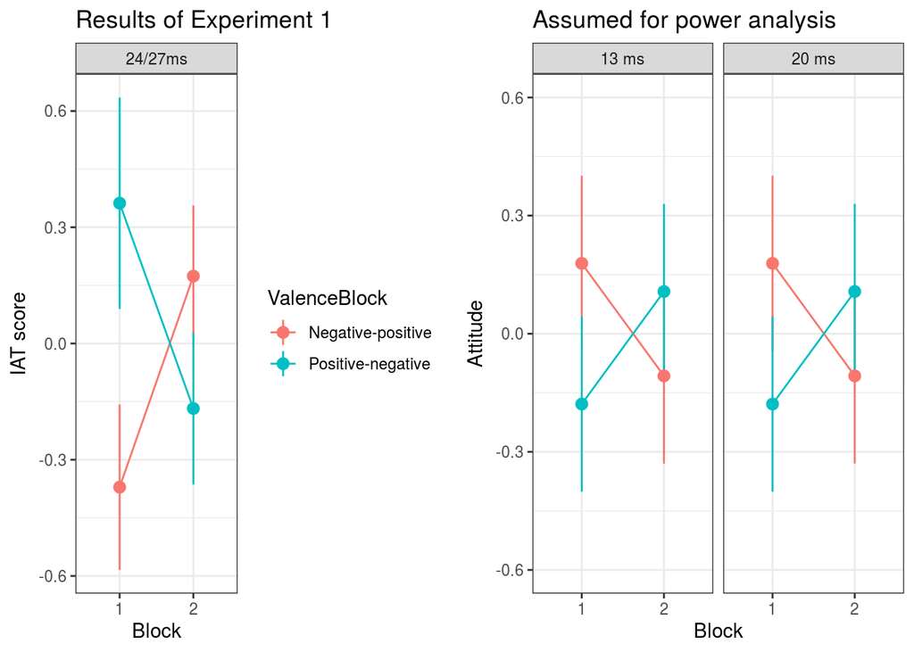

```r
otm2_power <- function(f, n, rm_cor = 0.5, alpha = 0.05) {
  contrast_codes <- tibble::tibble(
    time = rep(contr.treatment(2), 4)
    , order = rep(rep(contr.sum(2), each = 2), 2)
    , block = rep(contr.sum(2), each = 4)
    , time_block = time * block
    , time_order = time * order
    , block_order = block * order
    , time_block_order = time * block * order
  )

  mu <- with(
    contrast_codes
    , -order * 0.25*f +
      -block_order * f
  )

  string <- "2w*2b*2b"
  labelnames <- c("block", "1", "2", "order", "p-n", "n-p", "time", "13", "20")

  design_result <- ANOVA_design(
    design = string
    , n = n
    , mu = mu
    , sd = 1
    , r = rm_cor
    , labelnames = labelnames
  )

  ANOVA_exact(
    design_result
    , alpha_level = alpha_level
    , emm = TRUE
    , verbose = FALSE
    , contrast_type = "pairwise"
    , emm_comp = "block | time * order"
  )
}


otm2_n <- 320/4

# 95% power
otm2_pes <- 0.02027
otm2_dz <- pes_to_dz(otm2_pes, otm2_n, n_groups = 4)
rho <- 0.5
f <- dz_to_f(otm2_dz, rho)


otm2_int_power <- otm2_power(f = f, n = otm2_n, rm_cor = rho, alpha = 0.05)

otm1_observed <- readRDS("../../otm1/results/data_processed/otm1_attitudes_cleaned.rds") %>%
    mutate(`IAT score` = scale(IATscore) %>% as.vector)

otm1_observed_iat_plot <- otm1_observed %>%
  ggplot(aes(x = Block, y = `IAT score`, color = ValenceBlock, group = ValenceBlock)) +
    stat_summary(fun.y = mean, geom = "line") +
    stat_summary(fun.data = mean_cl_normal) +
    facet_grid(~ "24/27ms") +
    theme_bw() +
    ggtitle("Results of Experiment 1")

otm2_expected_plot <- otm2_int_power$dataframe %>%
  mutate(
    order = ifelse(order == "order_n-p", "Negative-positive", "Positive-negative")
    , block = ifelse(block == "block_1", "1", "2")
    , time = ifelse(time == "time_13", "13 ms", "20 ms")
  ) %>%
  ggplot(aes(x = block, y = y, color = order, group = order)) +
    stat_summary(fun.y = mean, geom = "line") +
    stat_summary(fun.data = mean_cl_normal) +
    coord_cartesian(ylim = c(-0.6, 0.6)) +
    facet_grid(~ time) +
    guides(color = FALSE) +
    ggtitle("Assumed for power analysis") +
    labs(x = "Block", y = "Attitude") +
    theme_bw()

plot_grid(
  otm1_observed_iat_plot
  , otm2_expected_plot
  , ncol = 2
)
```

```r
# 95% power
(otm2_pes <- 0.03973071)
```

```
## [1] 0.03973071
```

```r
(otm2_dz <- pes_to_dz(otm2_pes, otm2_n, n_groups = 4))
```

```
## [1] 0.4042641
```

```r
# rho <- 0.5
# f <- dz_to_f(otm2_dz, rho)
#
# otm2_contrast_power <- otm2_power(f = f, n = otm2_n, rm_cor = rho)$emmeans$contrasts %>%
#   emmeans_power(alpha = 0.05) %>%
#   .[1, ]
# otm2_contrast_power


# 80% power
(otm2_pes2 <- 0.0243813)
```

```
## [1] 0.0243813
```

```r
(otm2_dz2 <- pes_to_dz(otm2_pes2, otm2_n, n_groups = 4))
```

```
## [1] 0.3141861
```

```r
# f <- dz_to_f(otm2_dz2, rho)
#
# otm2_contrast_power2 <- otm2_power(f = f, n = otm2_n, rm_cor = rho)$emmeans$contrasts %>%
#   emmeans_power(alpha = 0.05) %>%
#   .[1, ]
# otm2_contrast_power2
```

```r
# 95% power
(otm2_dz_between_collapsed <- f_to_dz(dz_to_f(otm2_dz, rho) / sqrt(2), rho))
```

```
## [1] 0.2858579
```

```r
(otm2_pes_between_collapsed <- dz_to_pes(otm2_dz_between_collapsed, otm2_n, n_groups = 4))
```

```
## [1] 0.02026799
```

```r
# f <- dz_to_f(otm2_dz_between_collapsed, rho)
#
# otm2_time_collapsed_contrast_power <- otm2_power(f = f, n = otm2_n, rm_cor = rho)$emmeans$emmeans %>%
#   emmeans(specs = ~ block | order) %>%
#   pairs %>%
#   emmeans_power(alpha = 0.05) %>%
#   .[1, ]
# otm2_time_collapsed_contrast_power

# 80% power
(otm2_dz2_between_collapsed <- f_to_dz(dz_to_f(otm2_dz2, rho) / sqrt(2), rho))
```

```
## [1] 0.2221631
```

```r
(otm2_pes2_between_collapsed <- dz_to_pes(otm2_dz2_between_collapsed, otm2_n, n_groups = 4))
```

```
## [1] 0.0123411
```

```r
# f <- dz_to_f(otm2_dz2_between_collapsed, rho)
#
# otm2_time_collapsed_contrast_power2 <- otm2_power(f = f, n = otm2_n, rm_cor = rho)$emmeans$emmeans %>%
#   emmeans(specs = ~ block | order) %>%
#   pairs %>%
#   emmeans_power(alpha = 0.05) %>%
#   .[1, ]
# otm2_time_collapsed_contrast_power2
```

```r
# (Same results apply to two-way and three-way interaction)

# 95% power
(otm2_dz_collapsed <- f_to_dz(dz_to_f(otm2_dz, rho) / sqrt(4), rho))
```

```
## [1] 0.2021321
```

```r
(otm2_pes_collapsed <- dz_to_pes(otm2_dz_collapsed, otm2_n, n_groups = 4))
```

```
## [1] 0.01023774
```

```r
# f <- dz_to_f(otm2_dz_collapsed, rho)
#
# otm2_collapsed_contrast_power <- otm2_power(f = f, n = otm2_n, rm_cor = rho)$emmeans$emmeans %>%
#   emmeans(specs = ~ block * order) %>%
#   contrast(method = list(collapsed = c(-0.5, 0.5, 0.5, -0.5))) %>%
#   emmeans_power(alpha_level = 0.05)
# otm2_collapsed_contrast_power

# 80% power
(otm2_dz2_collapsed <- f_to_dz(dz_to_f(otm2_dz2, rho) / sqrt(4), rho))
```

```
## [1] 0.157093
```

```r
(otm2_pes2_collapsed <- dz_to_pes(otm2_dz2_collapsed, otm2_n, n_groups = 4))
```

```
## [1] 0.00620886
```

```r
# f <- dz_to_f(otm2_dz2_collapsed, rho)
#
# otm2_collapsed_contrast_power2 <- otm2_power(f = f, n = otm2_n, rm_cor = rho)$emmeans$emmeans %>%
#   emmeans(specs = ~ block * order) %>%
#   contrast(method = list(collapsed = c(-0.5, 0.5, 0.5, -0.5))) %>%
#   emmeans_power(alpha_level = 0.05)
# otm2_collapsed_contrast_power2
```

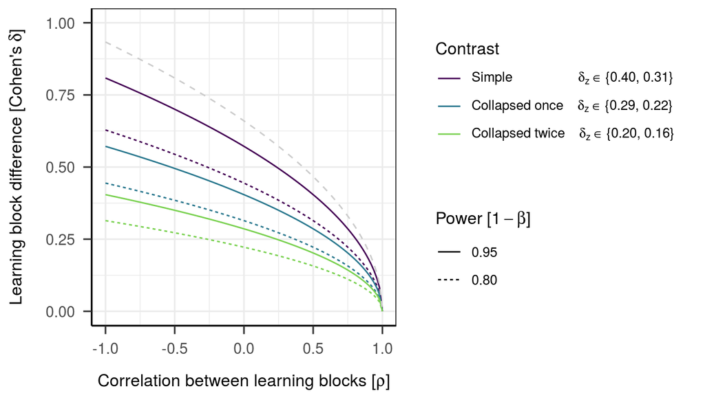

```r
rydell_power_curve <- tibble(
  rho = seq(-1, 1, length.out = 100)
  , delta = c(
    dz_to_f(rydell_dz, unique(rho)) * 2
    # dz_to_f(mean(heycke_dz), unique(rho)) * 2
  )
  , power = NA
)

otm1_power_curve <- tibble(
  rho = rep(seq(-1, 1, length.out = 100), 2)
  , delta = c(
    dz_to_f(otm1_dz, unique(rho)) * 2
    , dz_to_f(otm1_dz2, unique(rho)) * 2
  )
  , power = rep(c("0.95", "0.80"), each = length(rho)/2)
)

tibble(
  rho = rep(seq(-1, 1, length.out = 100), 2)
  , otm2_delta_simple = c(
    dz_to_f(otm2_dz, unique(rho)) * 2
    , dz_to_f(otm2_dz2, unique(rho)) * 2
  )
  , otm2_delta_between_collapsed = c(
    dz_to_f(otm2_dz_between_collapsed, unique(rho)) * 2
    , dz_to_f(otm2_dz2_between_collapsed, unique(rho)) * 2
  )
  , otm2_delta_collapsed = c(
    dz_to_f(otm2_dz_collapsed, unique(rho)) * 2
    , dz_to_f(otm2_dz2_collapsed, unique(rho)) * 2
  )
  , power = rep(c("0.95", "0.80"), each = length(rho)/2)
) %>%
  pivot_longer(cols = matches("otm"), names_to = "contrast", values_to = "delta") %>%
  mutate(
    power = relevel(factor(power), "0.95")
    , contrast = gsub("otm2_delta_", "", contrast)
    , contrast = gsub("_", " ", contrast)
    , contrast = factor(contrast, levels = c("simple", "between collapsed", "collapsed"))
  ) %>%
  ggplot(aes(x = rho, y = delta, color = contrast, group = interaction(power, contrast), linetype = power)) +
  # ggplot(aes(x = rho, y = delta, color = power, group = power)) +
  geom_line() +
  # geom_line(data = otm1_power_curve, aes(group = power, linetype = power, color = "simple"), alpha = 0.3) +
  geom_line(data = rydell_power_curve, aes(group = power), color = grey(0.8), linetype = "dashed") +
  scale_color_viridis_d(
    end = 0.8
    , labels = c(
      bquote("Simple                 "~delta[z] %in% "{"*.(printnum(otm2_dz))*", "*.(printnum(otm2_dz2))*"}")
      , bquote("Collapsed once   "~delta[z] %in% "{"*.(printnum(otm2_dz_between_collapsed))*", "*.(printnum(otm2_dz2_between_collapsed))*"}")
      , bquote("Collapsed twice   "~delta[z] %in% "{"*.(printnum(otm2_dz_collapsed))*", "*.(printnum(otm2_dz2_collapsed))*"}")
    )
  ) +
  ylim(c(0, 1)) +
  labs(
    x = bquote("Correlation between learning blocks ["*rho*"]")
    , y = bquote("Learning block difference [Cohen's"~delta*"]")
    , color = "Contrast"
    , linetype = bquote("Power"~"["*1 - beta*"]")
  ) +
  theme_apa(box = TRUE) +
  theme(
    panel.grid.major.x = element_line()
    , panel.grid.major.y = element_line()
    , panel.grid.minor.x = element_line()
    , panel.grid.minor.y = element_line()
    # , legend.position = c(0.99, 0.99)
    # , legend.justification = c(1, 1)
    # , legend.background = element_rect(fill = scales::alpha("white", 0.5))
  )
```

### 2.1.1 Sensitivty for omnibus-tests

```r
# Main effect block and three-way interaction
otm2_power <- function(f, n, rm_cor = 0.5, alpha = 0.05) {
  contrast_codes <- tibble::tibble(
    time = rep(contr.treatment(2), 4)
    , order = rep(rep(contr.sum(2), each = 2), 2)
    , block = rep(contr.sum(2), each = 4)
    , time_block = time * block
    , time_order = time * order
    , block_order = block * order
    , time_block_order = time * block * order
  )

  mu <- with(
    contrast_codes
    , #-order * 0.25*f +
      -block_order * f +
      -block * 0.5 * f +
      time_block_order * f
  )

  string <- "2w*2b*2b"
  labelnames <- c("block", "1", "2", "order", "p-n", "n-p", "time", "13", "20")

  design_result <- ANOVA_design(
    design = string
    , n = n
    , mu = mu
    , sd = 1
    , r = rm_cor
    , labelnames = labelnames
  )

  ANOVA_exact(
    design_result
    , alpha_level = alpha_level
    , emm = FALSE
    , verbose = FALSE
  )
}


otm2_n <- 320/4

# 95% power
otm2_pes <- 0.03973071
otm2_dz <- pes_to_dz(otm2_pes, otm2_n, n_groups = 4)
rho <- 0.5
f <- dz_to_f(otm2_dz, rho)


otm2_time_power <- otm2_power(f = f, n = otm2_n, rm_cor = rho, alpha = 0.05)
otm2_time_power$main_result
```

|  | power | partial_eta_squared | cohen_f | non_centrality |
| --- | --- | --- | --- | --- |
| order | 5.0000 | 0.0000000 | 0.0000000 | 0.00000 |
| time | 5.0000 | 0.0000000 | 0.0000000 | 0.00000 |
| order:time | 5.0000 | 0.0000000 | 0.0000000 | 0.00000 |
| block | 95.0002 | 0.0397307 | 0.2034074 | 13.07436 |
| order:block | 95.0002 | 0.0397307 | 0.2034074 | 13.07436 |
| time:block | 5.0000 | 0.0000000 | 0.0000000 | 0.00000 |
| order:time:block | 95.0002 | 0.0397307 | 0.2034074 | 13.07436 |

```r
# otm2_time_power$dataframe %>%
#   mutate(
#     order = ifelse(order == "order_n-p", "Negative-positive", "Positive-negative")
#     , block = ifelse(block == "block_1", "1", "2")
#     , time = ifelse(time == "time_13", "13 ms", "20 ms")
#   ) %>%
#   ggplot(aes(x = block, y = y, color = order, group = order)) +
#   stat_summary(fun.y = mean, geom = "line") +
#   stat_summary(fun.data = mean_cl_normal) +
#   coord_cartesian(ylim = c(-0.6, 0.6)) +
#   facet_grid(~ time) +
#   guides(color = FALSE) +
#   ggtitle("Assumed for power analysis") +
#   labs(x = "Block", y = "Attitude") +
#   theme_bw()

(otm2_dz_block <- f_to_dz(0.5*f, rho = 0.5))
```

```
## [1] 0.2021321
```

```r
(otm2_pes_block <- dz_to_pes(otm2_dz_block, otm2_n, n_groups = 4))
```

```
## [1] 0.01023774
```

```r
(otm2_dz_int <- f_to_dz(f, rho = 0.5))
```

```
## [1] 0.4042641
```

```r
(otm2_pes_int <- dz_to_pes(otm2_dz_int, otm2_n, n_groups = 4))
```

```
## [1] 0.03973071
```